# Reproducible Research: Peer Assessment 2: Analysis of weather events in US: What kills people and their wallets!

Abhee Brahmnalkar

August 18, 2015

## 1. Synopsis

This project involves exploring storm database maintained by the U.S. National Oceanic and Atmospheric Administration. This database maintains records of various weather events in US and their effects on society.

The purpose of this report is to answer two main questions as follows

- Across the United States, which types of events (as indicated in the EVTYPE variable) are most harmful with respect to population health?
- Across the United States, which types of events have the greatest economic consequences?

## 2. Data Processing

The required data for this project is maintained at https://d396qusza40orc.cloudfront.net/repdata%2Fdata%2FStormData.csv.bz2. The below code will check for directory and create if necessary. Then it will check for project file if it was previously downloaded and then download the file from link above if necessary. It will then read the content of the file into an object called Storm_Data.

*Note: Reading this file is a time consuming task. Be patient!*

```r
setwd("/Users/abheebrahmnalkar/Desktop/datasciencecoursera/RR")
if(!file.exists("./RR-P2")){dir.create("./RR-P2")
         setwd("/Users/abheebrahmnalkar/Desktop/datasciencecoursera/RR/RR-P2")
         fileUrl <- "http://d396qusza40orc.cloudfront.net/repdata%2Fdata%2FStormData.csv.bz2"
         download.file(fileUrl, destfile = "./repdata-data-StormData.csv.bz2", method = 'curl')
         print("Created directory, downloaded and unzipped files")
}

if(file.exists("./RR-P2")) {
    setwd("/Users/abheebrahmnalkar/Desktop/datasciencecoursera/RR/RR-P2")
    if(!file.exists("repdata-data-StormData.csv.bz2")) {
        fileUrl <- "https://d396qusza40orc.cloudfront.net/repdata%2Fdata%2FStormData.csv.bz2"
        download.file(fileUrl, destfile = "./repdata-data-StormData.csv.bz2", method = "curl")
        print("File had to be downloaded again")
    }
}

# Read the file if it's not already read
if(!exists("Storm_Data")){
    Storm_Data <- read.csv("repdata-data-StormData.csv.bz2", header = TRUE)
}
```

### Data cleaning and processing

Following chunk will subset the data. And change the letter case of EVTYPE column. Changing letter case is important as without that the program assumes events like ‘Coastal Flooding’, ‘COASTAL FLOODING’ and ‘coastal flooding’ as separate entities. This skews results.

```r
#SUBSETTING THE DATA
Subset_Storm_Data <- Storm_Data[, c("EVTYPE", "FATALITIES", "INJURIES", "PROPDMG", "PROPDMGEXP", "CROPDMG", "CROPDMGEXP")]

#Change the case
## change class to character so the below loop works
Subset_Storm_Data$EVTYPE <- as.character(Subset_Storm_Data$EVTYPE)
#loop
Subset_Storm_Data <- data.frame(lapply(Subset_Storm_Data, function(v) {
    if (is.character(v)) return(toupper(v))
    else return(v)
}))

## Apply ddply on fatalities and injuries.
library(plyr)
Health_Storm_Data <- ddply(Subset_Storm_Data, "EVTYPE", summarize, Totfat = sum(FATALITIES), Totinj = sum(INJURIES))
```

Take a peak at the unique values of EVTYPE. This will give you an idea of the cleanup job ahead of you.

```r
sort(unique(Health_Storm_Data$EVTYPE))
```

```
##   [1]    HIGH SURF ADVISORY           COASTAL FLOOD
##   [3]  FLASH FLOOD                    LIGHTNING
##   [5]  TSTM WIND                      TSTM WIND (G45)
##   [7]  WATERSPOUT                     WIND
##   [9] ?                              ABNORMAL WARMTH
##  [11] ABNORMALLY DRY                 ABNORMALLY WET
##  [13] ACCUMULATED SNOWFALL           AGRICULTURAL FREEZE
##  [15] APACHE COUNTY                  ASTRONOMICAL HIGH TIDE
##  [17] ASTRONOMICAL LOW TIDE          AVALANCE
##  [19] AVALANCHE                      BEACH EROSIN
##  [21] BEACH EROSION                  BEACH EROSION/COASTAL FLOOD
##  [23] BEACH FLOOD                    BELOW NORMAL PRECIPITATION
##  [25] BITTER WIND CHILL              BITTER WIND CHILL TEMPERATURES
##  [27] BLACK ICE                      BLIZZARD
##  [29] BLIZZARD AND EXTREME WIND CHIL BLIZZARD AND HEAVY SNOW
```

[output cut: 435 more lines]

### Cleaning code

The reason I wrote so much of cleaning code is that I had a hunch that lot of simple events like Sleet and Snow will have more impact to fatalities and crop damage but that is hidden in this data because of spelling mistakes and same event being categorized as different ’EVTYPE’s. Tornados and Hurricanes are obvious big bullies but let’s see if aggregate damage by these seemingly commonplace weather events has a bigger impact or not. Sit tight…

```r
Subset_Storm_Data$EVTYPE <- gsub(".*TSTM.*", "TSTM", Subset_Storm_Data$EVTYPE)
Subset_Storm_Data$EVTYPE <- gsub(".*THUNDERSTORM WIND.*", "TSTM", Subset_Storm_Data$EVTYPE)
Subset_Storm_Data$EVTYPE <- gsub(".*THUDERSTORM WINDS.*", "TSTM", Subset_Storm_Data$EVTYPE)
Subset_Storm_Data$EVTYPE <- gsub(".*THUNDEERSTORM WINDS.*", "TSTM", Subset_Storm_Data$EVTYPE)
Subset_Storm_Data$EVTYPE <- gsub(".*THUNDERESTORM WINDS.*", "TSTM", Subset_Storm_Data$EVTYPE)
Subset_Storm_Data$EVTYPE <- gsub(".*THUNDERSTORM  WINDS.*", "TSTM", Subset_Storm_Data$EVTYPE)
Subset_Storm_Data$EVTYPE <- gsub(".*THUNDERSTORM W INDS.*", "TSTM", Subset_Storm_Data$EVTYPE)
Subset_Storm_Data$EVTYPE <- gsub(".*THUNDERSTORM WINS.*", "TSTM", Subset_Storm_Data$EVTYPE)
Subset_Storm_Data$EVTYPE <- gsub(".*THUNDERSTORMS.*", "TSTM", Subset_Storm_Data$EVTYPE)
Subset_Storm_Data$EVTYPE <- gsub(".*THUNDERSTORMS WIND.*", "TSTM", Subset_Storm_Data$EVTYPE)
Subset_Storm_Data$EVTYPE <- gsub(".*THUNDERSTORMS WINDS.*", "TSTM", Subset_Storm_Data$EVTYPE)
Subset_Storm_Data$EVTYPE <- gsub(".*THUNDERSTORMW.*", "TSTM", Subset_Storm_Data$EVTYPE)
Subset_Storm_Data$EVTYPE <- gsub(".*THUNDERSTORMW 50.*", "TSTM", Subset_Storm_Data$EVTYPE)
Subset_Storm_Data$EVTYPE <- gsub(".*THUNDERSTORMW WINDS.*", "TSTM", Subset_Storm_Data$EVTYPE)
Subset_Storm_Data$EVTYPE <- gsub(".*THUNDERSTORMWINDS.*", "TSTM", Subset_Storm_Data$EVTYPE)
Subset_Storm_Data$EVTYPE <- gsub(".*THUNDERSTROM WIND.*", "TSTM", Subset_Storm_Data$EVTYPE)
Subset_Storm_Data$EVTYPE <- gsub(".*THUNDERSTROM WINDS.*", "TSTM", Subset_Storm_Data$EVTYPE)
Subset_Storm_Data$EVTYPE <- gsub(".*THUNDERTORM WINDS.*", "TSTM", Subset_Storm_Data$EVTYPE)
Subset_Storm_Data$EVTYPE <- gsub(".*THUNDERTSORM WIND.*", "TSTM", Subset_Storm_Data$EVTYPE)
Subset_Storm_Data$EVTYPE <- gsub(".*THUNDESTORM WINDS.*", "TSTM", Subset_Storm_Data$EVTYPE)
Subset_Storm_Data$EVTYPE <- gsub(".*THUNERSTORM WINDS.*", "TSTM", Subset_Storm_Data$EVTYPE)
Subset_Storm_Data$EVTYPE <- gsub(".*THUNDERSTORM.*", "TSTM", Subset_Storm_Data$EVTYPE)
Subset_Storm_Data$EVTYPE <- gsub(".*THUNDERSTORM DAMAGE.*", "TSTM", Subset_Storm_Data$EVTYPE)
Subset_Storm_Data$EVTYPE <- gsub(".*THUNDERSTORM DAMAGE TO.*", "TSTM", Subset_Storm_Data$EVTYPE)
Subset_Storm_Data$EVTYPE <- gsub(".*THUNDERSTORM HAIL.*", "TSTM", Subset_Storm_Data$EVTYPE) # HAIL MIGHT HAVE BIGGER IMPACT ON CROP DAMAGE. STILL CLUBBING IT UNDER THUNDERSTORM.
Subset_Storm_Data$EVTYPE <- gsub(".*WINDS.*", "WIND", Subset_Storm_Data$EVTYPE)
Subset_Storm_Data$EVTYPE <- gsub(".*WND.*", "WIND", Subset_Storm_Data$EVTYPE)
Subset_Storm_Data$EVTYPE <- gsub(".* WIND.*", "WIND", Subset_Storm_Data$EVTYPE)
Subset_Storm_Data$EVTYPE <- gsub(".*WIND CHILL/HIGH WIND.*", "WIND CHILL", Subset_Storm_Data$EVTYPE)
Subset_Storm_Data$EVTYPE <- gsub(".*WINTER STORM HIGH WINDS.*", "WINTER STORM", Subset_Storm_Data$EVTYPE)
Subset_Storm_Data$EVTYPE <- gsub(".*WINTER STORM/HIGH WIND.*", "WINTER STORM", Subset_Storm_Data$EVTYPE)
Subset_Storm_Data$EVTYPE <- gsub(".*WINTER STORM/HIGH WINDS.*", "WINTER STORM", Subset_Storm_Data$EVTYPE)
Subset_Storm_Data$EVTYPE <- gsub(".*WINTER STORMS.*", "WINTER STORM", Subset_Storm_Data$EVTYPE)
Subset_Storm_Data$EVTYPE <- gsub(".*WINTER WEATHER MIX.*", "WINTER WEATHER", Subset_Storm_Data$EVTYPE)
Subset_Storm_Data$EVTYPE <- gsub(".*WINTER WEATHER/MIX.*", "WINTER WEATHER", Subset_Storm_Data$EVTYPE)
Subset_Storm_Data$EVTYPE <- gsub(".*WINTERY MIX.*", "WINTER WEATHER", Subset_Storm_Data$EVTYPE)
Subset_Storm_Data$EVTYPE <- gsub(".*WINTRY MIX.*", "WINTER WEATHER", Subset_Storm_Data$EVTYPE)
Subset_Storm_Data$EVTYPE <- gsub(".*AVALANCE.*", "AVALANCHE", Subset_Storm_Data$EVTYPE)
Subset_Storm_Data$EVTYPE <- gsub(".* COASTAL FLOOD.*", "BEACH FLOOD", Subset_Storm_Data$EVTYPE)
Subset_Storm_Data$EVTYPE <- gsub(".* FLASH FLOOD.*", "FLASH FLOOD", Subset_Storm_Data$EVTYPE)
Subset_Storm_Data$EVTYPE <- gsub(".*FLASH FLOOD/.*", "FLASH FLOOD", Subset_Storm_Data$EVTYPE)
Subset_Storm_Data$EVTYPE <- gsub(".*FLASH FLOOD/ FLOOD.*", "FLASH FLOOD", Subset_Storm_Data$EVTYPE)
Subset_Storm_Data$EVTYPE <- gsub(".*FLASH FLOOD/FLOOD.*", "FLASH FLOOD", Subset_Storm_Data$EVTYPE)
Subset_Storm_Data$EVTYPE <- gsub(".*FLASH FLOOD/ STREET.*", "FLASH FLOOD", Subset_Storm_Data$EVTYPE)
Subset_Storm_Data$EVTYPE <- gsub(".*FLASH FLOODING.*", "FLASH FLOOD", Subset_Storm_Data$EVTYPE)
Subset_Storm_Data$EVTYPE <- gsub(".*FLOOD FLASH.*", "FLASH FLOOD", Subset_Storm_Data$EVTYPE)
Subset_Storm_Data$EVTYPE <- gsub(".*FLOOD/FLASH.*", "FLASH FLOOD", Subset_Storm_Data$EVTYPE)
Subset_Storm_Data$EVTYPE <- gsub(".*FLOOD FLOOD/FLASH.*", "FLASH FLOOD", Subset_Storm_Data$EVTYPE)
Subset_Storm_Data$EVTYPE <- gsub(".*FLOOD/FLASH FLOOD.*", "FLASH FLOOD", Subset_Storm_Data$EVTYPE)
Subset_Storm_Data$EVTYPE <- gsub(".*FLOOD/FLASH FLOODING.*", "FLASH FLOOD", Subset_Storm_Data$EVTYPE)
Subset_Storm_Data$EVTYPE <- gsub(".*FLOOD/FLASH/FLOOD.*", "FLASH FLOOD", Subset_Storm_Data$EVTYPE)
Subset_Storm_Data$EVTYPE <- gsub(".*FLOOD/FLASHFLOOD.*", "FLASH FLOOD", Subset_Storm_Data$EVTYPE)
Subset_Storm_Data$EVTYPE <- gsub(".*DRY MICROBURST.*", "DRY MICROBURST", Subset_Storm_Data$EVTYPE)
Subset_Storm_Data$EVTYPE <- gsub(".*FLASH FLOOD - HEAVY RAIN.*", "FLASH FLOOD", Subset_Storm_Data$EVTYPE)
Subset_Storm_Data$EVTYPE <- gsub(".*FLASH FLOOD FROM ICE JAMS.*", "FLASH FLOOD", Subset_Storm_Data$EVTYPE)
Subset_Storm_Data$EVTYPE <- gsub(".*FLASH FLOOD LANDSLIDES.*", "FLASH FLOOD", Subset_Storm_Data$EVTYPE)
Subset_Storm_Data$EVTYPE <- gsub(".*FLASH FLOODS.*", "FLASH FLOOD", Subset_Storm_Data$EVTYPE)
Subset_Storm_Data$EVTYPE <- gsub(".*FLASH FLOOODING.*", "FLASH FLOOD", Subset_Storm_Data$EVTYPE)
Subset_Storm_Data$EVTYPE <- gsub(".*DUST DEVEL.*", "DUST DEVIL", Subset_Storm_Data$EVTYPE)
Subset_Storm_Data$EVTYPE <- gsub(".*DUST DEVIL WATERSPOUT.*", "DUST DEVIL", Subset_Storm_Data$EVTYPE)
Subset_Storm_Data$EVTYPE <- gsub(".*DUSTSTORM.*", "DUST STORM", Subset_Storm_Data$EVTYPE)
Subset_Storm_Data$EVTYPE <- gsub(".*BEACH EROSIN.*", "BEACH EROSION", Subset_Storm_Data$EVTYPE)
Subset_Storm_Data$EVTYPE <- gsub(".*BEACH EROSION/COASTAL FLOOD.*", "BEACH EROSION", Subset_Storm_Data$EVTYPE)
Subset_Storm_Data$EVTYPE <- gsub(".*BEACH FLOOD.*", "BEACH EROSION", Subset_Storm_Data$EVTYPE)
Subset_Storm_Data$EVTYPE <- gsub(".*BLIZZARD SUMMARY.*", "BLIZZARD", Subset_Storm_Data$EVTYPE)
Subset_Storm_Data$EVTYPE <- gsub(".*BLIZZARD AND HEAVY SNOW.*", "BLIZZARD", Subset_Storm_Data$EVTYPE)
Subset_Storm_Data$EVTYPE <- gsub(".*BLIZZARD WEATHER.*", "BLIZZARD", Subset_Storm_Data$EVTYPE)
Subset_Storm_Data$EVTYPE <- gsub(".*BLIZZARD/FREEZING RAIN.*", "BLIZZARD", Subset_Storm_Data$EVTYPE)
Subset_Storm_Data$EVTYPE <- gsub(".*BLIZZARD/HEAVY SNOW.*", "BLIZZARD", Subset_Storm_Data$EVTYPE)
Subset_Storm_Data$EVTYPE <- gsub(".*BLIZZARD/WINTER STORM.*", "BLIZZARD", Subset_Storm_Data$EVTYPE)
Subset_Storm_Data$EVTYPE <- gsub(".*BRUSH FIRES.*", "BRUSH FIRE", Subset_Storm_Data$EVTYPE)
Subset_Storm_Data$EVTYPE <- gsub(".*COASTAL  FLOODING/EROSION.*", "COASTAL FLOOD", Subset_Storm_Data$EVTYPE)
Subset_Storm_Data$EVTYPE <- gsub(".*COASTAL EROSION.*", "COASTAL FLOOD", Subset_Storm_Data$EVTYPE)
Subset_Storm_Data$EVTYPE <- gsub(".*COASTAL FLOODING.*", "COASTAL FLOOD", Subset_Storm_Data$EVTYPE)
Subset_Storm_Data$EVTYPE <- gsub(".*COASTAL FLOODING/EROSION.*", "COASTAL FLOOD", Subset_Storm_Data$EVTYPE)
Subset_Storm_Data$EVTYPE <- gsub(".*COASTAL/TIDAL FLOOD.*", "COASTAL FLOOD", Subset_Storm_Data$EVTYPE)
Subset_Storm_Data$EVTYPE <- gsub(".*COASTALFLOOD.*", "COASTAL FLOOD", Subset_Storm_Data$EVTYPE)
Subset_Storm_Data$EVTYPE <- gsub(".*COASTALSTORM.*", "COASTAL STORM", Subset_Storm_Data$EVTYPE)
Subset_Storm_Data$EVTYPE <- gsub(".*CSTL FLOODING/EROSION.*", "COASTAL FLOOD", Subset_Storm_Data$EVTYPE)
Subset_Storm_Data$EVTYPE <- gsub(".*DAM BREAK.*", "DAM FAILURE", Subset_Storm_Data$EVTYPE)
Subset_Storm_Data$EVTYPE <- gsub(".*DROUGHT/EXCESSIVE HEAT.*", "DROUGHT", Subset_Storm_Data$EVTYPE)
Subset_Storm_Data$EVTYPE <- gsub(".*EXCESSIVE HEAT/DROUGHT.*", "DROUGHT", Subset_Storm_Data$EVTYPE)
Subset_Storm_Data$EVTYPE <- gsub(".*EROSION/CSTL FLOOD.*", "COASTAL FLOOD", Subset_Storm_Data$EVTYPE)
Subset_Storm_Data$EVTYPE <- gsub(".*EROSION/CSTL FLOOD.*", "COASTAL FLOOD", Subset_Storm_Data$EVTYPE)
Subset_Storm_Data$EVTYPE <- gsub(".*EXTREME COLD/WIND CHILL.*", "EXTREME COLD", Subset_Storm_Data$EVTYPE)
Subset_Storm_Data$EVTYPE <- gsub(".*EXTREME/RECORD COLD.*", "EXTREME COLD", Subset_Storm_Data$EVTYPE)
Subset_Storm_Data$EVTYPE <- gsub(".*FLOOD & HEAVY RAIN.*", "FLOOD", Subset_Storm_Data$EVTYPE)
Subset_Storm_Data$EVTYPE <- gsub(".*FLOODING.*", "FLOOD", Subset_Storm_Data$EVTYPE)
Subset_Storm_Data$EVTYPE <- gsub(".*FLOODING/HEAVY RAIN.*", "FLOOD", Subset_Storm_Data$EVTYPE)
Subset_Storm_Data$EVTYPE <- gsub(".*FLOOD/RAIN/WIND.*", "FLOOD", Subset_Storm_Data$EVTYPE)
Subset_Storm_Data$EVTYPE <- gsub(".*FLOODS.*", "FLOOD", Subset_Storm_Data$EVTYPE)
Subset_Storm_Data$EVTYPE <- gsub(".*FOG AND COLD TEMPERATURES.*", "FOG", Subset_Storm_Data$EVTYPE)
Subset_Storm_Data$EVTYPE <- gsub(".*FREEZING DRIZZLE AND FREEZING.*", "FREEZING DRIZZLE", Subset_Storm_Data$EVTYPE)
Subset_Storm_Data$EVTYPE <- gsub(".*FREEZING RAIN.*", "FREEZING DRIZZLE", Subset_Storm_Data$EVTYPE)
Subset_Storm_Data$EVTYPE <- gsub(".*FREEZING RAIN SLEET AND.*", "FREEZING RAIN AND SLEET", Subset_Storm_Data$EVTYPE)
Subset_Storm_Data$EVTYPE <- gsub(".*FREEZING RAIN SLEET AND LIGHT.*", "FREEZING RAIN AND SLEET", Subset_Storm_Data$EVTYPE)
Subset_Storm_Data$EVTYPE <- gsub(".*FREEZING RAIN/SLEET.*", "FREEZING RAIN AND SLEET", Subset_Storm_Data$EVTYPE)
Subset_Storm_Data$EVTYPE <- gsub(".*FREEZING RAIN/SNOW.*", "FREEZING RAIN AND SNOW", Subset_Storm_Data$EVTYPE)
Subset_Storm_Data$EVTYPE <- gsub(".*FROST/FREEZE.*", "FROST", Subset_Storm_Data$EVTYPE)
Subset_Storm_Data$EVTYPE <- gsub(".*FROST\\FREEZE.*", "FROST", Subset_Storm_Data$EVTYPE)
Subset_Storm_Data$EVTYPE <- gsub(".*FUNNEL CLOUD..*", "FUNNEL CLOUD", Subset_Storm_Data$EVTYPE)
Subset_Storm_Data$EVTYPE <- gsub(".*FUNNEL CLOUDS.*", "FUNNEL CLOUD", Subset_Storm_Data$EVTYPE)
Subset_Storm_Data$EVTYPE <- gsub(".*FUNNEL CLOUD/HAIL.*", "FUNNEL CLOUD", Subset_Storm_Data$EVTYPE)
Subset_Storm_Data$EVTYPE <- gsub(".*FUNNELS.*", "FUNNEL", Subset_Storm_Data$EVTYPE)
Subset_Storm_Data$EVTYPE <- gsub(".*GLAZE ICE.*", "GLAZE", Subset_Storm_Data$EVTYPE)
Subset_Storm_Data$EVTYPE <- gsub(".*GLAZE/ICE STORM.*", "GLAZE", Subset_Storm_Data$EVTYPE)
Subset_Storm_Data$EVTYPE <- gsub(".*GUSTNADO AND.*", "GUSTANDO", Subset_Storm_Data$EVTYPE)
Subset_Storm_Data$EVTYPE <- gsub(".*HAIL 0.75.*", "HAIL", Subset_Storm_Data$EVTYPE)
Subset_Storm_Data$EVTYPE <- gsub(".*HAIL 0.88.*", "HAIL", Subset_Storm_Data$EVTYPE)
Subset_Storm_Data$EVTYPE <- gsub(".*HAIL 075.*", "HAIL", Subset_Storm_Data$EVTYPE)
Subset_Storm_Data$EVTYPE <- gsub(".*HAIL 088.*", "HAIL", Subset_Storm_Data$EVTYPE)
Subset_Storm_Data$EVTYPE <- gsub(".*HAIL 1.00.*", "HAIL", Subset_Storm_Data$EVTYPE)
Subset_Storm_Data$EVTYPE <- gsub(".*HAIL 1.75.*", "HAIL", Subset_Storm_Data$EVTYPE)
Subset_Storm_Data$EVTYPE <- gsub(".*HAIL 1.75).*", "HAIL", Subset_Storm_Data$EVTYPE)
Subset_Storm_Data$EVTYPE <- gsub(".*HAIL 100.*", "HAIL", Subset_Storm_Data$EVTYPE)
Subset_Storm_Data$EVTYPE <- gsub(".*HAIL 125.*", "HAIL", Subset_Storm_Data$EVTYPE)
Subset_Storm_Data$EVTYPE <- gsub(".*HAIL 150.*", "HAIL", Subset_Storm_Data$EVTYPE)
Subset_Storm_Data$EVTYPE <- gsub(".*HAIL 175.*", "HAIL", Subset_Storm_Data$EVTYPE)
Subset_Storm_Data$EVTYPE <- gsub(".*HAIL 200.*", "HAIL", Subset_Storm_Data$EVTYPE)
Subset_Storm_Data$EVTYPE <- gsub(".*HAIL 225.*", "HAIL", Subset_Storm_Data$EVTYPE)
Subset_Storm_Data$EVTYPE <- gsub(".*HAIL 275.*", "HAIL", Subset_Storm_Data$EVTYPE)
Subset_Storm_Data$EVTYPE <- gsub(".*HAIL 450.*", "HAIL", Subset_Storm_Data$EVTYPE)
Subset_Storm_Data$EVTYPE <- gsub(".*HAIL 75.*", "HAIL", Subset_Storm_Data$EVTYPE)
Subset_Storm_Data$EVTYPE <- gsub(".*HAIL 80.*", "HAIL", Subset_Storm_Data$EVTYPE)
Subset_Storm_Data$EVTYPE <- gsub(".*HAIL 88.*", "HAIL", Subset_Storm_Data$EVTYPE)
Subset_Storm_Data$EVTYPE <- gsub(".*HAIL(0.75).*", "HAIL", Subset_Storm_Data$EVTYPE)
```

```r
Subset_Storm_Data$EVTYPE <- gsub(".*HAIL/ICY ROADS.*", "HAIL", Subset_Storm_Data$EVTYPE)
Subset_Storm_Data$EVTYPE <- gsub(".*HAIL/WIND.*", "HAIL", Subset_Storm_Data$EVTYPE)
Subset_Storm_Data$EVTYPE <- gsub(".*HAIL STORM.*", "HAIL", Subset_Storm_Data$EVTYPE)
Subset_Storm_Data$EVTYPE <- gsub(".*HAIL DAMAGE.*", "HAIL", Subset_Storm_Data$EVTYPE)
Subset_Storm_Data$EVTYPE <- gsub(".*HAIL ALOFT.*", "HAIL", Subset_Storm_Data$EVTYPE)
Subset_Storm_Data$EVTYPE <- gsub(".*LATE SEASON HAIL.*", "HAIL", Subset_Storm_Data$EVTYPE)
Subset_Storm_Data$EVTYPE <- gsub(".*HEAT DROUGHT.*", "HEAT", Subset_Storm_Data$EVTYPE)
Subset_Storm_Data$EVTYPE <- gsub(".*HEAT WAVE.*", "HEAT", Subset_Storm_Data$EVTYPE)
Subset_Storm_Data$EVTYPE <- gsub(".*HEAT WAVE DROUGHT.*", "HEAT", Subset_Storm_Data$EVTYPE)
Subset_Storm_Data$EVTYPE <- gsub(".*HEAT WAVES.*", "HEAT", Subset_Storm_Data$EVTYPE)
Subset_Storm_Data$EVTYPE <- gsub(".*HEAT/DROUGHT.*", "HEAT", Subset_Storm_Data$EVTYPE)
Subset_Storm_Data$EVTYPE <- gsub(".*HEATBURST.*", "HEAT", Subset_Storm_Data$EVTYPE)
Subset_Storm_Data$EVTYPE <- gsub(".*HEAVY PRECIPATATION.*", "HEAVY RAIN", Subset_Storm_Data$EVTYPE)
Subset_Storm_Data$EVTYPE <- gsub(".*HEAVY PRECIPITATION.*", "HEAVY RAIN", Subset_Storm_Data$EVTYPE)
Subset_Storm_Data$EVTYPE <- gsub(".*HEAVY RAIN AND FLOOD.*", "HEAVY RAIN", Subset_Storm_Data$EVTYPE)
Subset_Storm_Data$EVTYPE <- gsub(".*HEAVY RAIN EFFECTS.*", "HEAVY RAIN", Subset_Storm_Data$EVTYPE)
Subset_Storm_Data$EVTYPE <- gsub(".*HEAVY RAIN/HIGH SURF.*", "HEAVY RAIN", Subset_Storm_Data$EVTYPE)
Subset_Storm_Data$EVTYPE <- gsub(".*HEAVY RAIN/LIGHTNING.*", "HEAVY RAIN", Subset_Storm_Data$EVTYPE)
Subset_Storm_Data$EVTYPE <- gsub(".*HEAVY RAIN/MUDSLIDES/FLOOD.*", "HEAVY RAIN", Subset_Storm_Data$EVTYPE)
Subset_Storm_Data$EVTYPE <- gsub(".*HEAVY RAIN/SEVERE WEATHER.*", "HEAVY RAIN", Subset_Storm_Data$EVTYPE)
Subset_Storm_Data$EVTYPE <- gsub(".*HEAVY RAIN/SMALL STREAM URBAN.*", "HEAVY RAIN", Subset_Storm_Data$EVTYPE)
Subset_Storm_Data$EVTYPE <- gsub(".*HEAVY RAIN/SNOW.*", "HEAVY RAIN", Subset_Storm_Data$EVTYPE)
Subset_Storm_Data$EVTYPE <- gsub(".*HEAVY RAIN/URBAN FLOOD.*", "HEAVY RAIN", Subset_Storm_Data$EVTYPE)
Subset_Storm_Data$EVTYPE <- gsub(".*HEAVY RAIN/WIND.*", "HEAVY RAIN", Subset_Storm_Data$EVTYPE)
Subset_Storm_Data$EVTYPE <- gsub(".*HEAVY RAINFALL.*", "HEAVY RAIN", Subset_Storm_Data$EVTYPE)
Subset_Storm_Data$EVTYPE <- gsub(".*HEAVY RAINS.*", "HEAVY RAIN", Subset_Storm_Data$EVTYPE)
Subset_Storm_Data$EVTYPE <- gsub(".*HEAVY SHOWER.*", "HEAVY RAIN", Subset_Storm_Data$EVTYPE)
Subset_Storm_Data$EVTYPE <- gsub(".*HEAVY SHOWERS.*", "HEAVY RAIN", Subset_Storm_Data$EVTYPE)
Subset_Storm_Data$EVTYPE <- gsub(".*HVY RAIN.*", "HEAVY RAIN", Subset_Storm_Data$EVTYPE)
Subset_Storm_Data$EVTYPE <- gsub(".*HEAVY SNOW & ICE.*", "HEAVY SNOW", Subset_Storm_Data$EVTYPE)
Subset_Storm_Data$EVTYPE <- gsub(".*HEAVY SNOW AND.*", "HEAVY SNOW", Subset_Storm_Data$EVTYPE)
Subset_Storm_Data$EVTYPE <- gsub(".*HEAVY SNOW AND ICE.*", "HEAVY SNOW", Subset_Storm_Data$EVTYPE)
Subset_Storm_Data$EVTYPE <- gsub(".*HEAVY SNOW AND ICE STORM.*", "HEAVY SNOW", Subset_Storm_Data$EVTYPE)
Subset_Storm_Data$EVTYPE <- gsub(".*HEAVY SNOW ANDBLOWING SNOW.*", "HEAVY SNOW", Subset_Storm_Data$EVTYPE)
Subset_Storm_Data$EVTYPE <- gsub(".*HEAVY SNOW SHOWER.*", "HEAVY SNOW", Subset_Storm_Data$EVTYPE)
Subset_Storm_Data$EVTYPE <- gsub(".*HEAVY SNOW SQUALLS.*", "HEAVY SNOW", Subset_Storm_Data$EVTYPE)
Subset_Storm_Data$EVTYPE <- gsub(".*HEAVY SNOW-SQUALLS.*", "HEAVY SNOW", Subset_Storm_Data$EVTYPE)
Subset_Storm_Data$EVTYPE <- gsub(".*HEAVY SNOW/BLIZZARD.*", "HEAVY SNOW", Subset_Storm_Data$EVTYPE)
Subset_Storm_Data$EVTYPE <- gsub(".*HEAVY SNOW/BLIZZARD/AVALANCHE.*", "HEAVY SNOW", Subset_Storm_Data$EVTYPE)
Subset_Storm_Data$EVTYPE <- gsub(".*HEAVY SNOW/BLOWING SNOW.*", "HEAVY SNOW", Subset_Storm_Data$EVTYPE)
Subset_Storm_Data$EVTYPE <- gsub(".*HEAVY SNOW/HIGH.*", "HEAVY SNOW", Subset_Storm_Data$EVTYPE)
Subset_Storm_Data$EVTYPE <- gsub(".*HEAVY SNOW/ICE.*", "HEAVY SNOW", Subset_Storm_Data$EVTYPE)
Subset_Storm_Data$EVTYPE <- gsub(".*HEAVY SNOW/ICE STORM.*", "HEAVY SNOW", Subset_Storm_Data$EVTYPE)
Subset_Storm_Data$EVTYPE <- gsub(".*HEAVY SNOW/SLEET.*", "HEAVY SNOW", Subset_Storm_Data$EVTYPE)
Subset_Storm_Data$EVTYPE <- gsub(".*HEAVY SNOW/SQUALLS.*", "HEAVY SNOW", Subset_Storm_Data$EVTYPE)
Subset_Storm_Data$EVTYPE <- gsub(".*HEAVY SNOW/WIND.*", "HEAVY SNOW", Subset_Storm_Data$EVTYPE)
Subset_Storm_Data$EVTYPE <- gsub(".*HEAVY SNOW/WINTER STORM.*", "HEAVY SNOW", Subset_Storm_Data$EVTYPE)
Subset_Storm_Data$EVTYPE <- gsub(".*HEAVY SNOWPACK.*", "HEAVY SNOW", Subset_Storm_Data$EVTYPE)
Subset_Storm_Data$EVTYPE <- gsub(".*HEAVY WET SNOW.*", "HEAVY SNOW", Subset_Storm_Data$EVTYPE)
Subset_Storm_Data$EVTYPE <- gsub(".*HEAVY SURF/HIGH SURF.*", "HEAVY SURF", Subset_Storm_Data$EVTYPE)
Subset_Storm_Data$EVTYPE <- gsub(".*HEAVY SWELLS.*", "HEAVY SURF", Subset_Storm_Data$EVTYPE)
Subset_Storm_Data$EVTYPE <- gsub(".*HIGH  SWELLS.*", "HEAVY SURF", Subset_Storm_Data$EVTYPE)
Subset_Storm_Data$EVTYPE <- gsub(".*HIGH SURF.*", "HEAVY SURF", Subset_Storm_Data$EVTYPE)
Subset_Storm_Data$EVTYPE <- gsub(".*HIGH SURF ADVISORIES.*", "HEAVY SURF", Subset_Storm_Data$EVTYPE)
Subset_Storm_Data$EVTYPE <- gsub(".*HIGH SURF ADVISORY.*", "HEAVY SURF", Subset_Storm_Data$EVTYPE)
Subset_Storm_Data$EVTYPE <- gsub(".*HIGH SWELLS.*", "HEAVY SURF", Subset_Storm_Data$EVTYPE)
Subset_Storm_Data$EVTYPE <- gsub(".*HIGH WAVES.*", "HEAVY SURF", Subset_Storm_Data$EVTYPE)
Subset_Storm_Data$EVTYPE <- gsub(".*ICE AND SNOW.*", "ICE", Subset_Storm_Data$EVTYPE)
Subset_Storm_Data$EVTYPE <- gsub(".*ICE PELLETS.*", "FREEZING RAIN AND SLEET", Subset_Storm_Data$EVTYPE)
Subset_Storm_Data$EVTYPE <- gsub(".*ICE ON ROAD.*", "ICE ROADS", Subset_Storm_Data$EVTYPE)
Subset_Storm_Data$EVTYPE <- gsub(".*ICY ROADS.*", "ICE ROADS", Subset_Storm_Data$EVTYPE)
Subset_Storm_Data$EVTYPE <- gsub(".*ICE AND SNOW.*", "ICE", Subset_Storm_Data$EVTYPE)
Subset_Storm_Data$EVTYPE <- gsub(".*ICE STORM AND SNOW.*", "FREEZING RAIN AND SLEET", Subset_Storm_Data$EVTYPE)
Subset_Storm_Data$EVTYPE <- gsub(".*ICE STORM/FLASH FLOOD.*", "FREEZING RAIN AND SLEET", Subset_Storm_Data$EVTYPE)
Subset_Storm_Data$EVTYPE <- gsub(".*ICESTORM/BLIZZARD.*", "FREEZING RAIN AND SLEET", Subset_Storm_Data$EVTYPE)
Subset_Storm_Data$EVTYPE <- gsub(".*LANDSLIDE/URBAN FLOOD.*", "LANDSLIDE", Subset_Storm_Data$EVTYPE)
Subset_Storm_Data$EVTYPE <- gsub(".*LANDSLIDES.*", "LANDSLIDE", Subset_Storm_Data$EVTYPE)
Subset_Storm_Data$EVTYPE <- gsub(".*LATE-SEASON SNOWFALL.*", "LATE SNOW", Subset_Storm_Data$EVTYPE)
Subset_Storm_Data$EVTYPE <- gsub(".*LIGHTING.*", "LIGHTNING", Subset_Storm_Data$EVTYPE)
Subset_Storm_Data$EVTYPE <- gsub(".*LIGHTNING..*", "LIGHTNING", Subset_Storm_Data$EVTYPE)
Subset_Storm_Data$EVTYPE <- gsub(".*LIGHTNING AND HEAVY RAIN.*", "LIGHTNING", Subset_Storm_Data$EVTYPE)
Subset_Storm_Data$EVTYPE <- gsub(".*LIGHTNING AND HEAVY RAIN.*", "LIGHTNING", Subset_Storm_Data$EVTYPE)
Subset_Storm_Data$EVTYPE <- gsub(".*LIGHTNING  WAUSEON.*", "LIGHTNING", Subset_Storm_Data$EVTYPE)
Subset_Storm_Data$EVTYPE <- gsub(".*LIGHTNING DAMAGE.*", "LIGHTNING", Subset_Storm_Data$EVTYPE)
Subset_Storm_Data$EVTYPE <- gsub(".*LIGHTNING FIRE.*", "LIGHTNING", Subset_Storm_Data$EVTYPE)
Subset_Storm_Data$EVTYPE <- gsub(".*LIGNTNING.*", "LIGHTNING", Subset_Storm_Data$EVTYPE)
Subset_Storm_Data$EVTYPE <- gsub(".*LIGHTNING/HEAVY RAIN.*", "LIGHTNING", Subset_Storm_Data$EVTYPE)
Subset_Storm_Data$EVTYPE <- gsub(".*LOCALLY HEAVY RAIN.*", "HEAVY RAIN", Subset_Storm_Data$EVTYPE)
Subset_Storm_Data$EVTYPE <- gsub(".*LOCAL FLOOD.*", "FLOOD", Subset_Storm_Data$EVTYPE)
Subset_Storm_Data$EVTYPE <- gsub(".*MAJOR FLOOD.*", "FLOOD", Subset_Storm_Data$EVTYPE)
Subset_Storm_Data$EVTYPE <- gsub(".*MINOR FLOOD.*", "FLOOD", Subset_Storm_Data$EVTYPE)
Subset_Storm_Data$EVTYPE <- gsub(".*MARINE MISHAP.*", "MARINE ACCIDENT", Subset_Storm_Data$EVTYPE)
Subset_Storm_Data$EVTYPE <- gsub(".*MIXED PRECIP.*", "MIXED PRECIPITATION", Subset_Storm_Data$EVTYPE)
Subset_Storm_Data$EVTYPE <- gsub(".*MONTHLY RAINFALL.*", "MIXED PRECIPITATION", Subset_Storm_Data$EVTYPE)
Subset_Storm_Data$EVTYPE <- gsub(".*MUD SLIDE.*", "MUDSLIDE", Subset_Storm_Data$EVTYPE)
Subset_Storm_Data$EVTYPE <- gsub(".*MUD SLIDES.*", "MUDSLIDE", Subset_Storm_Data$EVTYPE)
Subset_Storm_Data$EVTYPE <- gsub(".*MUD/ROCK SLIDE.*", "MUDSLIDE", Subset_Storm_Data$EVTYPE)
Subset_Storm_Data$EVTYPE <- gsub(".*MUDSLIDE/LANDSLIDE.*", "MUDSLIDE", Subset_Storm_Data$EVTYPE)
Subset_Storm_Data$EVTYPE <- gsub(".*MUDSLIDES.*", "MUDSLIDE", Subset_Storm_Data$EVTYPE)
Subset_Storm_Data$EVTYPE <- gsub(".*ROCK SLIDE.*", "MUDSLIDE", Subset_Storm_Data$EVTYPE)
Subset_Storm_Data$EVTYPE <- gsub(".*RAIN (HEAVY).*", "HEAVY RAIN", Subset_Storm_Data$EVTYPE)
Subset_Storm_Data$EVTYPE <- gsub(".*RAIN/SNOW.*", "RAIN", Subset_Storm_Data$EVTYPE)
Subset_Storm_Data$EVTYPE <- gsub(".*RAIN/WIND.*", "RAIN", Subset_Storm_Data$EVTYPE)
Subset_Storm_Data$EVTYPE <- gsub(".*RAINSTORM.*", "HEAVY RAIN", Subset_Storm_Data$EVTYPE)
Subset_Storm_Data$EVTYPE <- gsub(".*RECORD  COLD.*", "RECORD COLD", Subset_Storm_Data$EVTYPE)
Subset_Storm_Data$EVTYPE <- gsub(".*RECORD COLD/FROST.*", "RECORD COLD", Subset_Storm_Data$EVTYPE)
Subset_Storm_Data$EVTYPE <- gsub(".*RECORD COOL.*", "RECORD COLD", Subset_Storm_Data$EVTYPE)
Subset_Storm_Data$EVTYPE <- gsub(".*RECORD SNOW/COLD.*", "RECORD SNOW", Subset_Storm_Data$EVTYPE)
Subset_Storm_Data$EVTYPE <- gsub(".*RECORD DRY MONTH.*", "RECORD DRYNESS", Subset_Storm_Data$EVTYPE)
Subset_Storm_Data$EVTYPE <- gsub(".*RECORD HEAT WAVE.*", "RECORD HEAT", Subset_Storm_Data$EVTYPE)
Subset_Storm_Data$EVTYPE <- gsub(".*RECORD/EXCESSIVE HEAT.*", "RECORD HEAT", Subset_Storm_Data$EVTYPE)
Subset_Storm_Data$EVTYPE <- gsub(".*RECORD HIGH TEMPERATURE.*", "RECORD HEAT", Subset_Storm_Data$EVTYPE)
Subset_Storm_Data$EVTYPE <- gsub(".*RECORD TEMPERATURE.*", "RECORD HEAT", Subset_Storm_Data$EVTYPE)
Subset_Storm_Data$EVTYPE <- gsub(".*RECORD TEMPERATURES.*", "RECORD HEAT", Subset_Storm_Data$EVTYPE)
Subset_Storm_Data$EVTYPE <- gsub(".*RECORD WARM TEMPS..*", "RECORD WARM", Subset_Storm_Data$EVTYPE)
Subset_Storm_Data$EVTYPE <- gsub(".*RECORD WARMTH.*", "RECORD WARM", Subset_Storm_Data$EVTYPE)
Subset_Storm_Data$EVTYPE <- gsub(".*RECORD WINTER SNOW.*", "RECORD SNOW", Subset_Storm_Data$EVTYPE)
Subset_Storm_Data$EVTYPE <- gsub(".*SLEET STORM.*", "SLEET", Subset_Storm_Data$EVTYPE)
Subset_Storm_Data$EVTYPE <- gsub(".*SLEET/ICE STORM.*", "SLEET", Subset_Storm_Data$EVTYPE)
Subset_Storm_Data$EVTYPE <- gsub(".*SLEET/RAIN/SNOW.*", "SLEET", Subset_Storm_Data$EVTYPE)
Subset_Storm_Data$EVTYPE <- gsub(".*SLEET/SNOW.*", "SLEET", Subset_Storm_Data$EVTYPE)
Subset_Storm_Data$EVTYPE <- gsub(".*SMALL HAIL.*", "HAIL", Subset_Storm_Data$EVTYPE)
Subset_Storm_Data$EVTYPE <- gsub(".*SMALL STREAM AND.*", "SMALL STREAM", Subset_Storm_Data$EVTYPE)
Subset_Storm_Data$EVTYPE <- gsub(".*SMALL STREAM AND URBAN FLOOD.*", "SMALL STREAM", Subset_Storm_Data$EVTYPE)
Subset_Storm_Data$EVTYPE <- gsub(".*SMALL STREAM/URBAN FLOOD.*", "SMALL STREAM", Subset_Storm_Data$EVTYPE)
Subset_Storm_Data$EVTYPE <- gsub(".*SML STREAM FLD.*", "SMALL STREAM", Subset_Storm_Data$EVTYPE)
Subset_Storm_Data$EVTYPE <- gsub(".*SNOW SQUALLS.*", "SNOW", Subset_Storm_Data$EVTYPE)
Subset_Storm_Data$EVTYPE <- gsub(".*SNOW SQUALL.*", "SNOW", Subset_Storm_Data$EVTYPE)
Subset_Storm_Data$EVTYPE <- gsub(".*SNOW ADVISORY.*", "SNOW", Subset_Storm_Data$EVTYPE)
Subset_Storm_Data$EVTYPE <- gsub(".*SNOW AND COLD.*", "SNOW", Subset_Storm_Data$EVTYPE)
Subset_Storm_Data$EVTYPE <- gsub(".*SNOW AND HEAVY SNOW.*", "SNOW", Subset_Storm_Data$EVTYPE)
Subset_Storm_Data$EVTYPE <- gsub(".*SNOW AND ICE.*", "SNOW", Subset_Storm_Data$EVTYPE)
Subset_Storm_Data$EVTYPE <- gsub(".*SNOW AND ICE STORM.*", "SNOW", Subset_Storm_Data$EVTYPE)
Subset_Storm_Data$EVTYPE <- gsub(".*SNOW AND SLEET.*", "SLEET", Subset_Storm_Data$EVTYPE)
Subset_Storm_Data$EVTYPE <- gsub(".*SNOW SHOWERS.*", "SNOW", Subset_Storm_Data$EVTYPE)
Subset_Storm_Data$EVTYPE <- gsub(".*SNOW SLEET.*", "SLEET", Subset_Storm_Data$EVTYPE)
```

```r
Subset_Storm_Data$EVTYPE <- gsub(".*SNOW/ BITTER COLD.*", "SNOW", Subset_Storm_Data$EVTYPE)
Subset_Storm_Data$EVTYPE <- gsub(".*SNOW/ ICE.*", "SNOW", Subset_Storm_Data$EVTYPE)
Subset_Storm_Data$EVTYPE <- gsub(".*SNOW/BLOWING SNOW.*", "SNOW", Subset_Storm_Data$EVTYPE)
Subset_Storm_Data$EVTYPE <- gsub(".*SNOW/COLD.*", "SNOW", Subset_Storm_Data$EVTYPE)
Subset_Storm_Data$EVTYPE <- gsub(".*SNOW/HEAVY SNOW.*", "SNOW", Subset_Storm_Data$EVTYPE)
Subset_Storm_Data$EVTYPE <- gsub(".*SNOW/ICE.*", "SNOW", Subset_Storm_Data$EVTYPE)
Subset_Storm_Data$EVTYPE <- gsub(".*SNOW/ICE STORM.*", "SNOW", Subset_Storm_Data$EVTYPE)
Subset_Storm_Data$EVTYPE <- gsub(".*SNOW/RAIN.*", "SNOW", Subset_Storm_Data$EVTYPE)
Subset_Storm_Data$EVTYPE <- gsub(".*SNOW/RAIN/SLEET.*", "SLEET", Subset_Storm_Data$EVTYPE)
Subset_Storm_Data$EVTYPE <- gsub(".*SNOW/SLEET.*", "SLEET", Subset_Storm_Data$EVTYPE)
Subset_Storm_Data$EVTYPE <- gsub(".*SNOW/SLEET/RAIN.*", "SNOW", Subset_Storm_Data$EVTYPE)
Subset_Storm_Data$EVTYPE <- gsub(".*SNOW\\COLD.*", "SNOW", Subset_Storm_Data$EVTYPE)
Subset_Storm_Data$EVTYPE <- gsub(".*SNOWFALL RECORD.*", "RECORD SNOW", Subset_Storm_Data$EVTYPE)
Subset_Storm_Data$EVTYPE <- gsub(".*STORM SURGE/TIDE.*", "STORM SURGE", Subset_Storm_Data$EVTYPE)
Subset_Storm_Data$EVTYPE <- gsub(".*TEMPERATURE RECORD.*", "RECORD HEAT", Subset_Storm_Data$EVTYPE)
Subset_Storm_Data$EVTYPE <- gsub(".*THUNDERSNOW.*", "SNOW", Subset_Storm_Data$EVTYPE)
Subset_Storm_Data$EVTYPE <- gsub(".*THUNDERSNOW SHOWER.*", "SNOW", Subset_Storm_Data$EVTYPE)
Subset_Storm_Data$EVTYPE <- gsub(".*TORNADO DEBRIS.*", "TORNADO", Subset_Storm_Data$EVTYPE)
Subset_Storm_Data$EVTYPE <- gsub(".*TORNADO F0.*", "TORNADO", Subset_Storm_Data$EVTYPE)
Subset_Storm_Data$EVTYPE <- gsub(".*TORNADO F1.*", "TORNADO", Subset_Storm_Data$EVTYPE)
Subset_Storm_Data$EVTYPE <- gsub(".*TORNADO F2.*", "TORNADO", Subset_Storm_Data$EVTYPE)
Subset_Storm_Data$EVTYPE <- gsub(".*TORNADO F3.*", "TORNADO", Subset_Storm_Data$EVTYPE)
Subset_Storm_Data$EVTYPE <- gsub(".*TORNADO/WATERSPOUT.*", "TORNADO", Subset_Storm_Data$EVTYPE)
Subset_Storm_Data$EVTYPE <- gsub(".*TORNADOES.*", "TORNADO", Subset_Storm_Data$EVTYPE)
Subset_Storm_Data$EVTYPE <- gsub(".*TORNADOS.*", "TORNADO", Subset_Storm_Data$EVTYPE)
Subset_Storm_Data$EVTYPE <- gsub(".*TORNDAO.*", "TORNADO", Subset_Storm_Data$EVTYPE)
Subset_Storm_Data$EVTYPE <- gsub(".*TORRENTIAL RAIN.*", "HEAVY RAIN", Subset_Storm_Data$EVTYPE)
Subset_Storm_Data$EVTYPE <- gsub(".*TORRENTIAL RAINFALL.*", "HEAVY RAIN", Subset_Storm_Data$EVTYPE)
Subset_Storm_Data$EVTYPE <- gsub(".*TROPICAL STORM ALBERTO.*", "TROPICAL STORM", Subset_Storm_Data$EVTYPE)
Subset_Storm_Data$EVTYPE <- gsub(".*TROPICAL STORM DEAN.*", "TROPICAL STORM", Subset_Storm_Data$EVTYPE)
Subset_Storm_Data$EVTYPE <- gsub(".*TROPICAL STORM GORDON.*", "TROPICAL STORM", Subset_Storm_Data$EVTYPE)
Subset_Storm_Data$EVTYPE <- gsub(".*TROPICAL STORM JERRY.*", "TROPICAL STORM", Subset_Storm_Data$EVTYPE)
Subset_Storm_Data$EVTYPE <- gsub(".*UNSEASONABLY COLD.*", "UNSEASONABLE COLD", Subset_Storm_Data$EVTYPE)
Subset_Storm_Data$EVTYPE <- gsub(".*UNSEASONABLY COOL.*", "UNSEASONABLE COLD", Subset_Storm_Data$EVTYPE)
Subset_Storm_Data$EVTYPE <- gsub(".*UNSEASONABLY COOL & WET.*", "UNSEASONABLE COLD", Subset_Storm_Data$EVTYPE)
Subset_Storm_Data$EVTYPE <- gsub(".*UNUSUALLY COLD.*", "UNSEASONABLE COLD", Subset_Storm_Data$EVTYPE)
Subset_Storm_Data$EVTYPE <- gsub(".*URBAN SMALL.*", "URBAN STREAM", Subset_Storm_Data$EVTYPE)
Subset_Storm_Data$EVTYPE <- gsub(".*URBAN SMALL STREAM FLOOD.*", "URBAN STREAM", Subset_Storm_Data$EVTYPE)
Subset_Storm_Data$EVTYPE <- gsub(".*URBAN/SMALL.*", "URBAN STREAM", Subset_Storm_Data$EVTYPE)
Subset_Storm_Data$EVTYPE <- gsub(".*URBAN/SMALL STREAM.*", "URBAN STREAM", Subset_Storm_Data$EVTYPE)
Subset_Storm_Data$EVTYPE <- gsub(".*URBAN/SMALL STREAM  FLOOD.*", "URBAN STREAM", Subset_Storm_Data$EVTYPE)
Subset_Storm_Data$EVTYPE <- gsub(".*URBAN/SMALL STREAM FLOOD.*", "URBAN STREAM", Subset_Storm_Data$EVTYPE)
Subset_Storm_Data$EVTYPE <- gsub(".*URBAN/SMALL STRM FLDG.*", "URBAN STREAM", Subset_Storm_Data$EVTYPE)
Subset_Storm_Data$EVTYPE <- gsub(".*URBAN/SML STREAM FLD.*", "URBAN STREAM", Subset_Storm_Data$EVTYPE)
Subset_Storm_Data$EVTYPE <- gsub(".*URBAN/SML STREAM FLDG.*", "URBAN STREAM", Subset_Storm_Data$EVTYPE)
Subset_Storm_Data$EVTYPE <- gsub(".*VOLCANIC ASH PLUME.*", "VOLCANIC ASH", Subset_Storm_Data$EVTYPE)
Subset_Storm_Data$EVTYPE <- gsub(".*VOLCANIC ASHFALL.*", "VOLCANIC ASH", Subset_Storm_Data$EVTYPE)
Subset_Storm_Data$EVTYPE <- gsub(".*WATER SPOUT.*", "WATERSPOUT", Subset_Storm_Data$EVTYPE)
Subset_Storm_Data$EVTYPE <- gsub(".*WATERSPOUT FUNNEL CLOUD.*", "WATERSPOUT", Subset_Storm_Data$EVTYPE)
Subset_Storm_Data$EVTYPE <- gsub(".*WATERSPOUT TORNADO.*", "TORNADO", Subset_Storm_Data$EVTYPE)
Subset_Storm_Data$EVTYPE <- gsub(".*WATERSPOUTS.*", "WATERSPOUT", Subset_Storm_Data$EVTYPE)
Subset_Storm_Data$EVTYPE <- gsub(".*WAYTERSPOUT.*", "WATERSPOUT", Subset_Storm_Data$EVTYPE)
Subset_Storm_Data$EVTYPE <- gsub(".*WATERSPOUT-TORNADO.*", "TORNADO", Subset_Storm_Data$EVTYPE)
Subset_Storm_Data$EVTYPE <- gsub(".*WATERSPOUT/TORNADO.*", "TORNADO", Subset_Storm_Data$EVTYPE)
Subset_Storm_Data$EVTYPE <- gsub(".*WATERSPOUT-.*", "WATERSPOUT", Subset_Storm_Data$EVTYPE)
Subset_Storm_Data$EVTYPE <- gsub(".*WATERSPOUT/.*", "WATERSPOUT", Subset_Storm_Data$EVTYPE)
Subset_Storm_Data$EVTYPE <- gsub(".*WILD FIRES.*", "WILD FIRE", Subset_Storm_Data$EVTYPE)
Subset_Storm_Data$EVTYPE <- gsub(".*WILD/FOREST FIRE.*", "WILD FIRE", Subset_Storm_Data$EVTYPE)
Subset_Storm_Data$EVTYPE <- gsub(".*WILD/FOREST FIRES.*", "WILD FIRE", Subset_Storm_Data$EVTYPE)
Subset_Storm_Data$EVTYPE <- gsub(".*WILDFIRE.*", "WILD FIRE", Subset_Storm_Data$EVTYPE)
Subset_Storm_Data$EVTYPE <- gsub(".*WILDFIRES.*", "WILD FIRE", Subset_Storm_Data$EVTYPE)
Subset_Storm_Data$EVTYPE <- gsub(".*WIND ADVISORY.*", "WIND", Subset_Storm_Data$EVTYPE)
Subset_Storm_Data$EVTYPE <- gsub(".*WIND AND WAVE.*", "WIND", Subset_Storm_Data$EVTYPE)
Subset_Storm_Data$EVTYPE <- gsub(".*WIND CHILL.*", "WIND", Subset_Storm_Data$EVTYPE)
Subset_Storm_Data$EVTYPE <- gsub(".*WIND DAMAGE.*", "WIND", Subset_Storm_Data$EVTYPE)
Subset_Storm_Data$EVTYPE <- gsub(".*WIND GUSTS.*", "WIND", Subset_Storm_Data$EVTYPE)
Subset_Storm_Data$EVTYPE <- gsub(".*WIND STORM.*", "WIND", Subset_Storm_Data$EVTYPE)
Subset_Storm_Data$EVTYPE <- gsub(".*WIND/HAIL.*", "HAIL", Subset_Storm_Data$EVTYPE)
Subset_Storm_Data$EVTYPE <- gsub(".*HURRICANE EDOUARD.*", "HURRICANE", Subset_Storm_Data$EVTYPE)
Subset_Storm_Data$EVTYPE <- gsub(".*HURRICANE EMILY.*", "HURRICANE", Subset_Storm_Data$EVTYPE)
Subset_Storm_Data$EVTYPE <- gsub(".*HURRICANE ERIN.*", "HURRICANE", Subset_Storm_Data$EVTYPE)
Subset_Storm_Data$EVTYPE <- gsub(".*HURRICANE FELIX.*", "HURRICANE", Subset_Storm_Data$EVTYPE)
Subset_Storm_Data$EVTYPE <- gsub(".*HURRICANE GORDON.*", "HURRICANE", Subset_Storm_Data$EVTYPE)
Subset_Storm_Data$EVTYPE <- gsub(".*HURRICANE OPAL.*", "HURRICANE", Subset_Storm_Data$EVTYPE)
Subset_Storm_Data$EVTYPE <- gsub(".*HURRICANE OPAL/HIGH WINDS.*", "HURRICANE", Subset_Storm_Data$EVTYPE)
Subset_Storm_Data$EVTYPE <- gsub(".*HURRICANE-GENERATED SWELLS.*", "HURRICANE", Subset_Storm_Data$EVTYPE)
Subset_Storm_Data$EVTYPE <- gsub(".*HURRICANE/TYPHOON.*", "HURRICANE", Subset_Storm_Data$EVTYPE)
```

```r
Health_Storm_Data <- ddply(Subset_Storm_Data, "EVTYPE", summarize, Totfat = sum(FATALITIES, na.rm = T), Totinj = sum(INJURIES, na.rm = T))
TopHurters <- Health_Storm_Data[order(-Health_Storm_Data$Totinj), ][1:6, c('EVTYPE', 'Totinj')]
TopKillers <- Health_Storm_Data[order(-Health_Storm_Data$Totfat), ][1:6, c('EVTYPE', 'Totfat')]
```

### Weather Event Analysis for Economical Consequences

The dataset contains Propdmg and Propdmgexp columns for data related to property damage. Similarly, Cropdmg and Cropdmgexp for damages related to crops. Let’s take a look at all the values for CROPDMGEXP and PROPDMGEXP

```r
unique(Storm_Data$CROPDMGEXP)
```

```
## [1]   M K m B ? 0 k 2
## Levels:  ? 0 2 B k K m M
```

```r
unique(Storm_Data$PROPDMGEXP)
```

```
##  [1] K M   B m + 0 5 6 ? 4 2 3 h 7 H - 1 8
## Levels:  - ? + 0 1 2 3 4 5 6 7 8 B h H K m M
```

The M stands for million, K stands for thousand, H for hundred and so on… Let’s assign proper numeric values in the data set so that we can perform mathematical operations later.

```r
Subset_Storm_Data$CROPDMGEXP <- as.character(Subset_Storm_Data$CROPDMGEXP)
Subset_Storm_Data$PROPDMGEXP <- as.character(Subset_Storm_Data$PROPDMGEXP)

Subset_Storm_Data$CROPDMGEXP[Subset_Storm_Data$CROPDMGEXP == ""] <- 1
Subset_Storm_Data$CROPDMGEXP[Subset_Storm_Data$CROPDMGEXP == "0"] <- 1
Subset_Storm_Data$CROPDMGEXP[Subset_Storm_Data$CROPDMGEXP == "?"] <- 0
Subset_Storm_Data$CROPDMGEXP[Subset_Storm_Data$CROPDMGEXP == "2"] <- 100
Subset_Storm_Data$CROPDMGEXP[Subset_Storm_Data$CROPDMGEXP == "B"] <- 1000000000
Subset_Storm_Data$CROPDMGEXP[Subset_Storm_Data$CROPDMGEXP == "K"] <- 1000
Subset_Storm_Data$CROPDMGEXP[Subset_Storm_Data$CROPDMGEXP == "k"] <- 1000
Subset_Storm_Data$CROPDMGEXP[Subset_Storm_Data$CROPDMGEXP == "m"] <- 1000000
Subset_Storm_Data$CROPDMGEXP[Subset_Storm_Data$CROPDMGEXP == "M"] <- 1000000

Subset_Storm_Data$PROPDMGEXP[Subset_Storm_Data$PROPDMGEXP == "-"] <- 1
Subset_Storm_Data$PROPDMGEXP[Subset_Storm_Data$PROPDMGEXP == "?"] <- 0
Subset_Storm_Data$PROPDMGEXP[Subset_Storm_Data$PROPDMGEXP == "0"] <- 1
Subset_Storm_Data$PROPDMGEXP[Subset_Storm_Data$PROPDMGEXP == "1"] <- 10
Subset_Storm_Data$PROPDMGEXP[Subset_Storm_Data$PROPDMGEXP == "2"] <- 100
Subset_Storm_Data$PROPDMGEXP[Subset_Storm_Data$PROPDMGEXP == "3"] <- 1000
Subset_Storm_Data$PROPDMGEXP[Subset_Storm_Data$PROPDMGEXP == "4"] <- 10000
Subset_Storm_Data$PROPDMGEXP[Subset_Storm_Data$PROPDMGEXP == "5"] <- 100000
Subset_Storm_Data$PROPDMGEXP[Subset_Storm_Data$PROPDMGEXP == "6"] <- 1000000
Subset_Storm_Data$PROPDMGEXP[Subset_Storm_Data$PROPDMGEXP == "7"] <- 10000000
Subset_Storm_Data$PROPDMGEXP[Subset_Storm_Data$PROPDMGEXP == "8"] <- 100000000
Subset_Storm_Data$PROPDMGEXP[Subset_Storm_Data$PROPDMGEXP == "B"] <- 1000000000
Subset_Storm_Data$PROPDMGEXP[Subset_Storm_Data$PROPDMGEXP == "h"] <- 100
Subset_Storm_Data$PROPDMGEXP[Subset_Storm_Data$PROPDMGEXP == "H"] <- 100
Subset_Storm_Data$PROPDMGEXP[Subset_Storm_Data$PROPDMGEXP == "K"] <- 1000
Subset_Storm_Data$PROPDMGEXP[Subset_Storm_Data$PROPDMGEXP == "m"] <- 1000000
Subset_Storm_Data$PROPDMGEXP[Subset_Storm_Data$PROPDMGEXP == "M"] <- 1000000
Subset_Storm_Data$PROPDMGEXP[Subset_Storm_Data$PROPDMGEXP == "+"] <- 1

Subset_Storm_Data$CROPDMGEXP <- as.numeric(Subset_Storm_Data$CROPDMGEXP)
Subset_Storm_Data$PROPDMGEXP <- as.numeric(Subset_Storm_Data$PROPDMGEXP)

Economic_Storm_Data <- ddply(Subset_Storm_Data, "EVTYPE", summarize, TotProp = sum(PROPDMG*PROPDMGEXP, na.rm = T), TotCrop = sum(CROPDMG*CROPDMGEXP, na.rm = T), TotLoss = sum(TotProp, TotCrop, na.rm = T))

TopProp <- Economic_Storm_Data[order(-Economic_Storm_Data$TotProp), ][1:6, c('EVTYPE', 'TotProp')]
TopCrop <- Economic_Storm_Data[order(-Economic_Storm_Data$TotCrop), ][1:6, c('EVTYPE', 'TotCrop')]
TopLoss <- Economic_Storm_Data[order(-Economic_Storm_Data$TotLoss), ][1:10, c('EVTYPE', 'TotLoss')]
```

## 3. Results

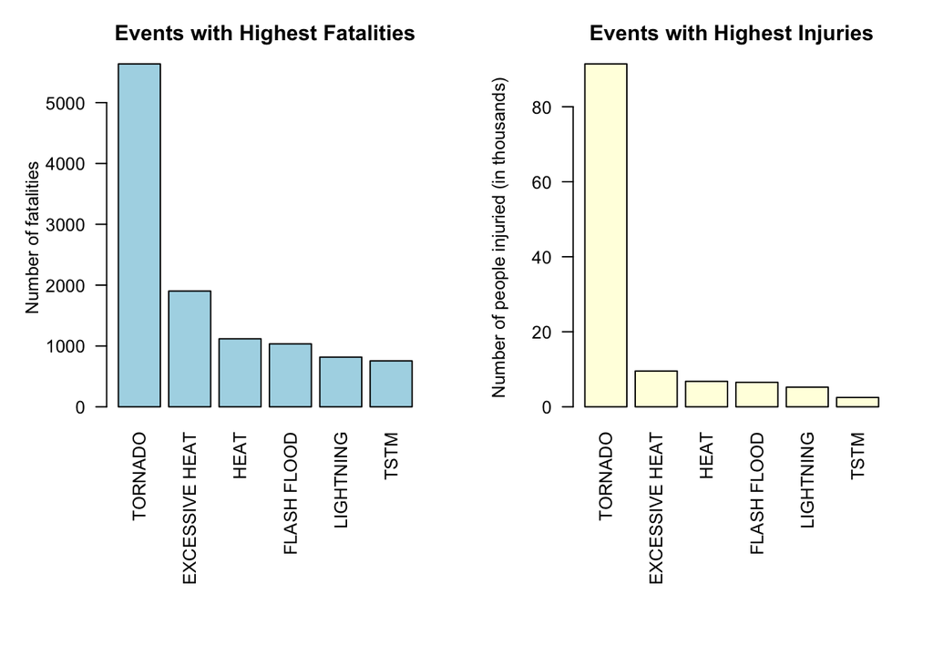

```r
par(mfrow = c(1, 2), mar = c(12, 5, 3, 2), mgp = c(3, 1, 0), cex = 0.8, oma = c(0,0,0,0))
barplot(TopKillers$Totfat, las = 2, names.arg = TopKillers$EVTYPE, main = "Events with Highest Fatalities", ylab = "Number of fatalities", col = "light blue")
barplot((TopHurters$Totinj/1000), las = 2, names.arg = TopKillers$EVTYPE, main = "Events with Highest Injuries", ylab = "Number of people injuried (in thousands)", col = "light yellow")
```

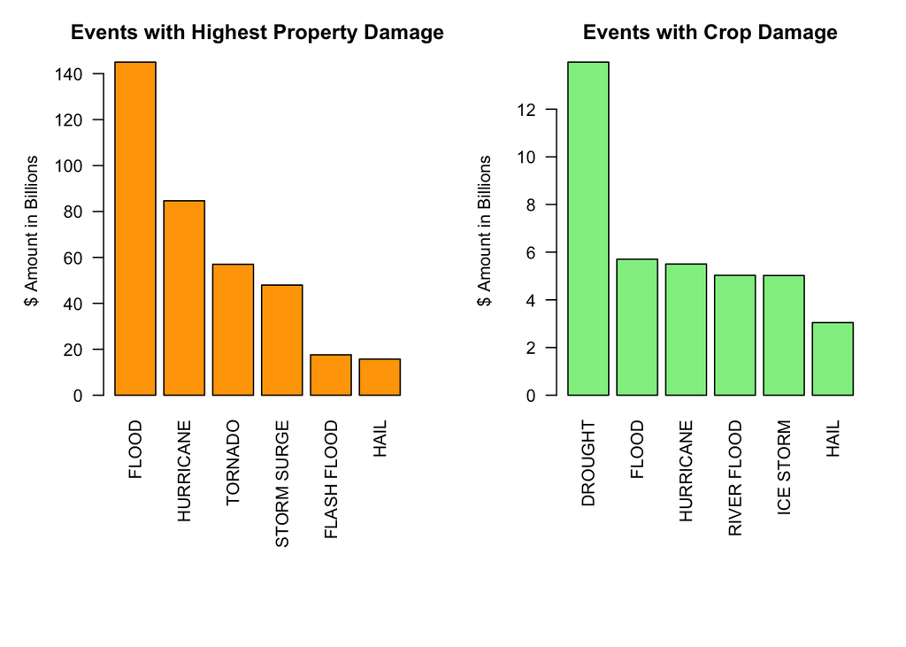

```r
par(mfrow = c(1, 2), mar = c(12, 5, 3, 2), mgp = c(3, 1, 0), cex = 0.8, oma = c(0,0,0,0))
barplot((TopProp$TotProp/1000000000), las = 2, names.arg = TopProp$EVTYPE, main = "Events with Highest Property Damage", ylab = "$ Amount in Billions", col = "orange")
barplot((TopCrop$TotCrop/1000000000), las = 2, names.arg = TopCrop$EVTYPE, main = "Events with Crop Damage", ylab = "$ Amount in Billions", col = "light green")
```

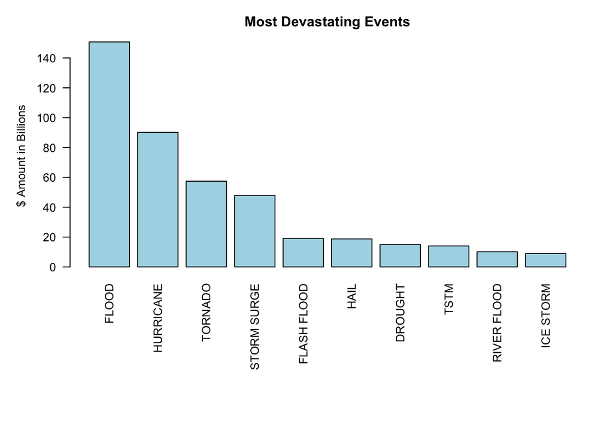

```r
par(mfrow = c(1, 1), mar = c(12, 5, 3, 2), mgp = c(3, 1, 0), cex = 0.8, oma = c(0,0,0,0))
barplot((TopLoss$TotLoss/1000000000), las = 2, names.arg = TopLoss$EVTYPE, main = "Most Devastating Events", ylab = "$ Amount in Billions", col = "light blue")
```

For the monetary damage, the first thing to notice is that magnitude of property damage is way to high as compared to the magnitude of crop damage. This is consistent as *generally* an acre of farmland produces 1000 dollars in a season on the other hand even a little damage to a car or a roof of the house will cause much higher repair bills.

Also from the graph it is clear that the worst events for the property damage is Flood followed by Hurricane and Tornado. Hail and Flashflood made the last two of the top six and I think that’s because of the damage they cause to automobiles in the urban area.

For Crops, obviously draught is the most devastating. Followed by Flood and Hurricane. River flood also seems to be logical as lot of farmland is in the vicinity of rivers. Ice storm and Hail destroy plant life especially when they are out of the season and they form the last two of the top six crop damaging weather events.